# Provision data quality report

**Author**: Greg Slater  
**Date**: November 2024  
**Dataset Scope**: ODP datasets  
**Report Type**: Ad-hoc

**Purpose**: The purpose of this report is to measure the quality of the data that makes up each data provision on the platform, by applying a data quality framework that sets out criteria that must be met in order to reach one of 4 different quality levels. These levels are based around the quality requirements of the ODP software which uses platform data.

Note: the datasets included in this report are active resources of active endpoints. So where we have retired endpoints we may have data for a provision still appearing on the platform but it will not appear in this report. This means in the "Dataset quality scoring detail" table not all ODP provisions are present, 68 compared to 73. This is because there are 5 ODP providers where we don't have endpoints or HE conservation-area data, so there are no issues to display.

Future improvements:

- Error handling. Queries not working may break bits of the report. Not very high priority while report is more of a POC.
- Base tables. Expand summaries to full ODP provision, including where no data at all. This could be done by switching the `qual_cat_summary` table to be constructed from a base of the provision table, rather than `qual_all` (which only includes provisions with quality issues).
- Adding more quality checks. This depends on more checks going live in issues or expectations tables, but once they are should be easy to add extra criteria checks through the `qual_` table structure.
- Include data from old endpoints. This will need re-working of the base table query (from `fi.get_endpoint_res_issues()`) to include old endpoints and resources. Though this will add complexity to work out which are the "latest" endpoints and resources to include, especially for provisions with multiple endpoints. May be low priority.

**Note**: the code has been removed from this version of the notebook in order to demo the visuals on https://digital-land.github.io.

### Data quality framework

The table below visualises the framework that is used to assign a quality level to each ODP data provision.

The criteria marked as "true" at each level must be met by a data provision in order for it to be scored at that level. The levels are cumulative, so all criteria must be met in order for a provision to be scored as *data that is trustworthy*. Where we have data from alternative providers (e.g. Historic England conservation-area data) the first criteria cannot be met so it is scored as the first quality level, *some data*.

[figure not shown]

## 4. Present

### Data quality overview chart - by dataset groups

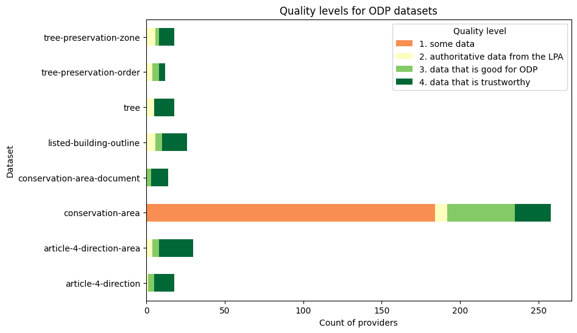

```python
# widgets.interact(make_quality_overview_chart, subset = subset_dropdown)
make_quality_overview_chart("ODP")
```

### Data quality overview map - for ODP datasets

```python
# widgets.interact(map_odp_quality_scores, dataset = odp_dataset_dropdown)
map_odp_quality_scores("conservation-area")
```

Make this Notebook Trusted to load map: File -> Trust Notebook

[interactive chart not shown]

### ODP LPA overview table by dataset & quality

```python
odp_lpa_summary_wide.style.apply(make_color_mask_odp_lpa, axis=None)
```

|  | cohort | organisation | organisation_name | article-4-direction | article-4-direction-area | conservation-area | conservation-area-document | listed-building-outline | tree | tree-preservation-order | tree-preservation-zone | ready_for_ODP_adoption |
| --- | --- | --- | --- | --- | --- | --- | --- | --- | --- | --- | --- | --- |
| 0 | ODP-Track1 | local-authority:BIR | Birmingham City Council | 4. data that is trustworthy | 4. data that is trustworthy | 4. data that is trustworthy | 4. data that is trustworthy | 2. authoritative data from the LPA | 0. no data | 0. no data | 2. authoritative data from the LPA | no |
| 1 | ODP-Track1 | local-authority:CAT | Canterbury City Council | 0. no data | 3. data that is good for ODP | 4. data that is trustworthy | 0. no data | 3. data that is good for ODP | 0. no data | 0. no data | 0. no data | no |
| 2 | ODP-Track1 | local-authority:EPS | Epsom and Ewell Borough Council | 3. data that is good for ODP | 4. data that is trustworthy | 3. data that is good for ODP | 0. no data | 4. data that is trustworthy | 4. data that is trustworthy | 3. data that is good for ODP | 4. data that is trustworthy | yes |
| 3 | ODP-Track1 | local-authority:BNE | London Borough of Barnet | 4. data that is trustworthy | 4. data that is trustworthy | 4. data that is trustworthy | 3. data that is good for ODP | 4. data that is trustworthy | 4. data that is trustworthy | 3. data that is good for ODP | 4. data that is trustworthy | yes |
| 4 | ODP-Track2 | local-authority:GAT | Gateshead Metropolitan Borough Council | 0. no data | 4. data that is trustworthy | 4. data that is trustworthy | 0. no data | 4. data that is trustworthy | 4. data that is trustworthy | 0. no data | 3. data that is good for ODP | yes |
| 5 | ODP-Track2 | local-authority:GRY | Great Yarmouth Borough Council | 0. no data | 4. data that is trustworthy | 3. data that is good for ODP | 0. no data | 4. data that is trustworthy | 0. no data | 4. data that is trustworthy | 4. data that is trustworthy | no |
| 6 | ODP-Track2 | local-authority:KTT | Royal Borough of Kingston upon Thames | 0. no data | 0. no data | 1. some data | 0. no data | 0. no data | 0. no data | 0. no data | 0. no data | no |
| 7 | ODP-Track2 | local-authority:SAL | St Albans City and District Council | 3. data that is good for ODP | 4. data that is trustworthy | 3. data that is good for ODP | 4. data that is trustworthy | 2. authoritative data from the LPA | 2. authoritative data from the LPA | 0. no data | 2. authoritative data from the LPA | yes |
| 8 | ODP-Track2 | local-authority:TEW | Tewkesbury Borough Council | 0. no data | 4. data that is trustworthy | 3. data that is good for ODP | 0. no data | 3. data that is good for ODP | 4. data that is trustworthy | 0. no data | 4. data that is trustworthy | yes |
| 9 | ODP-Track2 | local-authority:WBK | West Berkshire Council | 0. no data | 4. data that is trustworthy | 3. data that is good for ODP | 0. no data | 4. data that is trustworthy | 2. authoritative data from the LPA | 0. no data | 2. authoritative data from the LPA | yes |
| 10 | ODP-Track3 | local-authority:DST | Dorset Council | 0. no data | 0. no data | 3. data that is good for ODP | 0. no data | 0. no data | 0. no data | 0. no data | 0. no data | no |
| 11 | ODP-Track3 | local-authority:DOV | Dover District Council | 4. data that is trustworthy | 3. data that is good for ODP | 3. data that is good for ODP | 0. no data | 4. data that is trustworthy | 4. data that is trustworthy | 3. data that is good for ODP | 2. authoritative data from the LPA | yes |
| 12 | ODP-Track3 | local-authority:WFT | London Borough of Waltham Forest | 0. no data | 0. no data | 1. some data | 0. no data | 0. no data | 0. no data | 0. no data | 0. no data | no |
| 13 | ODP-Track3 | local-authority:NLN | North Lincolnshire Council | 4. data that is trustworthy | 4. data that is trustworthy | 4. data that is trustworthy | 4. data that is trustworthy | 4. data that is trustworthy | 4. data that is trustworthy | 4. data that is trustworthy | 4. data that is trustworthy | yes |
| 14 | ODP-Track3 | local-authority:NSM | North Somerset Council | 3. data that is good for ODP | 2. authoritative data from the LPA | 3. data that is good for ODP | 0. no data | 4. data that is trustworthy | 4. data that is trustworthy | 3. data that is good for ODP | 4. data that is trustworthy | yes |
| 15 | ODP-Track3 | local-authority:SLF | Salford City Council | 0. no data | 0. no data | 3. data that is good for ODP | 0. no data | 0. no data | 0. no data | 0. no data | 0. no data | no |
| 16 | ODP-Track3 | local-authority:WRL | Wirral Borough Council | 0. no data | 0. no data | 3. data that is good for ODP | 4. data that is trustworthy | 4. data that is trustworthy | 0. no data | 0. no data | 0. no data | no |
| 17 | ODP-Track4 | local-authority:ASF | Ashford Borough Council | 0. no data | 0. no data | 0. no data | 0. no data | 4. data that is trustworthy | 0. no data | 4. data that is trustworthy | 0. no data | no |
| 18 | ODP-Track4 | local-authority:BAI | Basildon Borough Council | 0. no data | 0. no data | 1. some data | 0. no data | 0. no data | 0. no data | 0. no data | 0. no data | no |
| 19 | ODP-Track4 | local-authority:BOL | Bolton Metropolitan Borough Council | 0. no data | 0. no data | 4. data that is trustworthy | 0. no data | 0. no data | 0. no data | 0. no data | 0. no data | no |
| 20 | ODP-Track4 | local-authority:BST | Bristol City Council | 4. data that is trustworthy | 3. data that is good for ODP | 3. data that is good for ODP | 4. data that is trustworthy | 3. data that is good for ODP | 4. data that is trustworthy | 4. data that is trustworthy | 4. data that is trustworthy | yes |
| 21 | ODP-Track4 | local-authority:BRO | Broadland District Council | 0. no data | 0. no data | 1. some data | 0. no data | 0. no data | 0. no data | 0. no data | 0. no data | no |
| 22 | ODP-Track4 | local-authority:CAS | Castle Point Borough Council | 4. data that is trustworthy | 4. data that is trustworthy | 4. data that is trustworthy | 4. data that is trustworthy | 4. data that is trustworthy | 0. no data | 0. no data | 0. no data | no |
| 23 | ODP-Track4 | local-authority:LND | City of London Corporation | 4. data that is trustworthy | 0. no data | 4. data that is trustworthy | 0. no data | 3. data that is good for ODP | 0. no data | 0. no data | 0. no data | no |
| 24 | ODP-Track4 | local-authority:WSM | City of Westminster | 0. no data | 0. no data | 1. some data | 0. no data | 0. no data | 0. no data | 0. no data | 0. no data | no |
| 25 | ODP-Track4 | local-authority:YOR | City of York Council | 0. no data | 0. no data | 3. data that is good for ODP | 0. no data | 0. no data | 0. no data | 0. no data | 0. no data | no |
| 26 | ODP-Track4 | local-authority:ECA | East Cambridgeshire District Council | 4. data that is trustworthy | 4. data that is trustworthy | 3. data that is good for ODP | 0. no data | 0. no data | 0. no data | 0. no data | 0. no data | no |
| 27 | ODP-Track4 | local-authority:EHA | East Hampshire District Council | 0. no data | 0. no data | 1. some data | 0. no data | 0. no data | 0. no data | 0. no data | 0. no data | no |
| 28 | ODP-Track4 | local-authority:EHE | East Hertfordshire District Council | 0. no data | 0. no data | 1. some data | 0. no data | 0. no data | 0. no data | 0. no data | 0. no data | no |
| 29 | ODP-Track4 | local-authority:HOR | Horsham District Council | 0. no data | 4. data that is trustworthy | 3. data that is good for ODP | 0. no data | 0. no data | 2. authoritative data from the LPA | 2. authoritative data from the LPA | 2. authoritative data from the LPA | no |
| 30 | ODP-Track4 | local-authority:LCE | Leicester City Council | 0. no data | 0. no data | 4. data that is trustworthy | 4. data that is trustworthy | 0. no data | 0. no data | 0. no data | 0. no data | no |
| 31 | ODP-Track4 | local-authority:BDG | London Borough of Barking and Dagenham | 0. no data | 2. authoritative data from the LPA | 4. data that is trustworthy | 0. no data | 4. data that is trustworthy | 0. no data | 0. no data | 0. no data | no |
| 32 | ODP-Track4 | local-authority:CRY | London Borough of Croydon | 0. no data | 0. no data | 1. some data | 0. no data | 0. no data | 0. no data | 0. no data | 0. no data | no |
| 33 | ODP-Track4 | local-authority:ENF | London Borough of Enfield | 0. no data | 4. data that is trustworthy | 3. data that is good for ODP | 0. no data | 0. no data | 0. no data | 0. no data | 0. no data | no |
| 34 | ODP-Track4 | local-authority:HNS | London Borough of Hounslow | 0. no data | 0. no data | 1. some data | 0. no data | 0. no data | 0. no data | 0. no data | 0. no data | no |
| 35 | ODP-Track4 | local-authority:TWH | London Borough of Tower Hamlets | 0. no data | 4. data that is trustworthy | 3. data that is good for ODP | 0. no data | 2. authoritative data from the LPA | 0. no data | 0. no data | 0. no data | no |
| 36 | ODP-Track4 | local-authority:MIK | Milton Keynes Council | 0. no data | 0. no data | 1. some data | 0. no data | 0. no data | 0. no data | 0. no data | 0. no data | no |
| 37 | ODP-Track4 | local-authority:NEW | New Forest District Council | 0. no data | 0. no data | 1. some data | 0. no data | 0. no data | 0. no data | 0. no data | 0. no data | no |
| 38 | ODP-Track4 | national-park-authority:Q72617158 | New Forest National Park Authority | 0. no data | 0. no data | 1. some data | 0. no data | 0. no data | 0. no data | 0. no data | 0. no data | no |
| 39 | ODP-Track4 | local-authority:NYUA | North Yorkshire Council | 0. no data | 0. no data | 3. data that is good for ODP | 0. no data | 0. no data | 0. no data | 0. no data | 0. no data | no |
| 40 | ODP-Track4 | local-authority:NBL | Northumberland County Council | 0. no data | 0. no data | 1. some data | 0. no data | 0. no data | 0. no data | 0. no data | 0. no data | no |
| 41 | ODP-Track4 | local-authority:PTE | Peterborough City Council | 0. no data | 0. no data | 3. data that is good for ODP | 4. data that is trustworthy | 0. no data | 0. no data | 0. no data | 0. no data | no |
| 42 | ODP-Track4 | local-authority:PLY | Plymouth City Council | 4. data that is trustworthy | 4. data that is trustworthy | 4. data that is trustworthy | 4. data that is trustworthy | 0. no data | 4. data that is trustworthy | 0. no data | 0. no data | no |
| 43 | ODP-Track4 | local-authority:RCH | Rochdale Metropolitan Borough Council | 0. no data | 0. no data | 1. some data | 0. no data | 0. no data | 0. no data | 0. no data | 0. no data | no |
| 44 | ODP-Track4 | local-authority:ROS | Rossendale Borough Council | 4. data that is trustworthy | 4. data that is trustworthy | 4. data that is trustworthy | 3. data that is good for ODP | 0. no data | 0. no data | 0. no data | 0. no data | no |
| 45 | ODP-Track4 | local-authority:ROH | Rother District Council | 0. no data | 0. no data | 4. data that is trustworthy | 3. data that is good for ODP | 0. no data | 0. no data | 0. no data | 0. no data | no |
| 46 | ODP-Track4 | local-authority:SAW | Sandwell Metropolitan Borough Council | 4. data that is trustworthy | 4. data that is trustworthy | 3. data that is good for ODP | 0. no data | 0. no data | 4. data that is trustworthy | 0. no data | 4. data that is trustworthy | no |
| 47 | ODP-Track4 | local-authority:SCA | South Cambridgeshire District Council | 0. no data | 0. no data | 1. some data | 0. no data | 0. no data | 0. no data | 0. no data | 0. no data | no |
| 48 | ODP-Track4 | local-authority:SGC | South Gloucestershire Council | 0. no data | 0. no data | 3. data that is good for ODP | 0. no data | 0. no data | 0. no data | 0. no data | 0. no data | no |
| 49 | ODP-Track4 | local-authority:SNO | South Norfolk District Council | 0. no data | 0. no data | 1. some data | 0. no data | 0. no data | 0. no data | 0. no data | 0. no data | no |
| 50 | ODP-Track4 | local-authority:SST | South Staffordshire Council | 4. data that is trustworthy | 0. no data | 1. some data | 0. no data | 0. no data | 0. no data | 0. no data | 0. no data | no |
| 51 | ODP-Track4 | local-authority:SPE | Spelthorne Borough Council | 0. no data | 0. no data | 1. some data | 0. no data | 0. no data | 0. no data | 0. no data | 0. no data | no |
| 52 | ODP-Track4 | local-authority:SUR | Surrey Heath Borough Council | 0. no data | 0. no data | 1. some data | 0. no data | 0. no data | 0. no data | 0. no data | 0. no data | no |
| 53 | ODP-Track4 | local-authority:TAN | Tandridge District Council | 0. no data | 0. no data | 1. some data | 0. no data | 0. no data | 0. no data | 0. no data | 0. no data | no |
| 54 | ODP-Track4 | local-authority:TEN | Tendring District Council | 0. no data | 0. no data | 1. some data | 0. no data | 0. no data | 0. no data | 0. no data | 0. no data | no |
| 55 | ODP-Track4 | local-authority:TOB | Torbay Council | 0. no data | 0. no data | 1. some data | 0. no data | 0. no data | 0. no data | 0. no data | 0. no data | no |
| 56 | ODP-Track4 | local-authority:TRF | Trafford Metropolitan Borough Council | 0. no data | 0. no data | 3. data that is good for ODP | 0. no data | 0. no data | 0. no data | 0. no data | 0. no data | no |
| 57 | ODP-Track4 | local-authority:WAE | Waverley Borough Council | 0. no data | 0. no data | 2. authoritative data from the LPA | 0. no data | 0. no data | 0. no data | 0. no data | 0. no data | no |
| 58 | RIPA-BOPS | local-authority:DAC | Dacorum Borough Council | 0. no data | 0. no data | 3. data that is good for ODP | 0. no data | 0. no data | 0. no data | 0. no data | 0. no data | no |
| 59 | RIPA-BOPS | local-authority:DNC | Doncaster Metropolitan Borough Council | 0. no data | 4. data that is trustworthy | 4. data that is trustworthy | 0. no data | 4. data that is trustworthy | 4. data that is trustworthy | 0. no data | 3. data that is good for ODP | yes |
| 60 | RIPA-BOPS | local-authority:GLO | Gloucester City Council | 0. no data | 4. data that is trustworthy | 4. data that is trustworthy | 0. no data | 4. data that is trustworthy | 4. data that is trustworthy | 0. no data | 4. data that is trustworthy | yes |
| 61 | RIPA-BOPS | local-authority:CMD | London Borough of Camden | 4. data that is trustworthy | 4. data that is trustworthy | 4. data that is trustworthy | 4. data that is trustworthy | 4. data that is trustworthy | 0. no data | 0. no data | 0. no data | no |
| 62 | RIPA-BOPS | local-authority:MDW | Medway Council | 0. no data | 4. data that is trustworthy | 3. data that is good for ODP | 0. no data | 2. authoritative data from the LPA | 0. no data | 0. no data | 0. no data | no |
| 63 | RIPA-BOPS | local-authority:NET | Newcastle City Council | 2. authoritative data from the LPA | 2. authoritative data from the LPA | 4. data that is trustworthy | 0. no data | 2. authoritative data from the LPA | 2. authoritative data from the LPA | 2. authoritative data from the LPA | 2. authoritative data from the LPA | yes |
| 64 | RIPA-BOPS | local-authority:NED | North East Derbyshire District Council | 0. no data | 0. no data | 3. data that is good for ODP | 0. no data | 0. no data | 0. no data | 0. no data | 0. no data | no |
| 65 | RIPA-Beta | local-authority:BUC | Buckinghamshire Council | 0. no data | 2. authoritative data from the LPA | 2. authoritative data from the LPA | 0. no data | 0. no data | 4. data that is trustworthy | 2. authoritative data from the LPA | 0. no data | no |
| 66 | RIPA-Beta | local-authority:LBH | London Borough of Lambeth | 3. data that is good for ODP | 3. data that is good for ODP | 4. data that is trustworthy | 0. no data | 2. authoritative data from the LPA | 2. authoritative data from the LPA | 2. authoritative data from the LPA | 0. no data | no |
| 67 | RIPA-Beta | local-authority:SWK | London Borough of Southwark | 0. no data | 4. data that is trustworthy | 3. data that is good for ODP | 0. no data | 4. data that is trustworthy | 0. no data | 0. no data | 4. data that is trustworthy | no |

### Dataset quality scoring detail table

```python
# widgets.interact(get_dataset_qual_detail, dataset = dataset_dropdown)
get_dataset_qual_detail("article-4-direction")
```

|  | pipeline | organisation | organisation_name | 1 - authoritative data from the LPA | 2 - no geometry errors | 2 - no unknown entity issues | 2 - unique reference values | 3 - entity count matches LPA | 3 - no other validity errors | quality_level_label |
| --- | --- | --- | --- | --- | --- | --- | --- | --- | --- | --- |
| 49 | article-4-direction | local-authority:BIR | Birmingham City Council | True | True | True | True | True | True | 4. data that is trustworthy |
| 50 | article-4-direction | local-authority:BNE | London Borough of Barnet | True | True | True | True | True | True | 4. data that is trustworthy |
| 51 | article-4-direction | local-authority:BST | Bristol City Council | True | True | True | True | True | True | 4. data that is trustworthy |
| 52 | article-4-direction | local-authority:CAS | Castle Point Borough Council | True | True | True | True | True | True | 4. data that is trustworthy |
| 53 | article-4-direction | local-authority:CMD | London Borough of Camden | True | True | True | True | True | True | 4. data that is trustworthy |
| 54 | article-4-direction | local-authority:DOV | Dover District Council | True | True | True | True | True | True | 4. data that is trustworthy |
| 55 | article-4-direction | local-authority:ECA | East Cambridgeshire District Council | True | True | True | True | True | True | 4. data that is trustworthy |
| 56 | article-4-direction | local-authority:EPS | Epsom and Ewell Borough Council | True | True | True | True | True | False | 3. data that is good for ODP |
| 57 | article-4-direction | local-authority:LBH | London Borough of Lambeth | True | True | True | True | True | False | 3. data that is good for ODP |
| 58 | article-4-direction | local-authority:LND | City of London Corporation | True | True | True | True | True | True | 4. data that is trustworthy |
| 59 | article-4-direction | local-authority:NET | Newcastle City Council | True | True | True | False | True | True | 2. authoritative data from the LPA |
| 60 | article-4-direction | local-authority:NLN | North Lincolnshire Council | True | True | True | True | True | True | 4. data that is trustworthy |
| 61 | article-4-direction | local-authority:NSM | North Somerset Council | True | True | True | True | True | False | 3. data that is good for ODP |
| 62 | article-4-direction | local-authority:PLY | Plymouth City Council | True | True | True | True | True | True | 4. data that is trustworthy |
| 63 | article-4-direction | local-authority:ROS | Rossendale Borough Council | True | True | True | True | True | True | 4. data that is trustworthy |
| 64 | article-4-direction | local-authority:SAL | St Albans City and District Council | True | True | True | True | True | False | 3. data that is good for ODP |
| 65 | article-4-direction | local-authority:SAW | Sandwell Metropolitan Borough Council | True | True | True | True | True | True | 4. data that is trustworthy |
| 66 | article-4-direction | local-authority:SST | South Staffordshire Council | True | True | True | True | True | True | 4. data that is trustworthy |

### Output

Save report files

```python
fn = os.path.join(output_dir, f"quality_ODP-dataset-scores-by-LPA_{td}.xlsx")
odp_lpa_summary_wide.style.apply(make_color_mask_odp_lpa, axis=None).to_excel(fn, index = False)
```

```python
fn = os.path.join(output_dir, f"quality_dataset-quality-detail_{td}.csv")
qual_cat_summary_wide.to_csv(fn)
```